# Devil May Cry 3 Special Edition Speedrun World Record Progression 2019-Present

Time Series Forecast

BanHitGaming

12/03/2026

# Introduction

Devil May Cry 3: Dante’s Awakening (DMC 3) is a PlayStation 2 video game originally released in 2005, developed and published by Capcom. It was later re-released in 2006 as Devil May Cry 3: Dante’s Awakening Special Edition (DMC 3 SE) on the PlayStation 2 and is the most common version of the game ported on to modern systems and digital store fronts today as it fixes and adjusts the difficulty problem in the original release and balancing other gameplay elements.

Speedrunning in its simplest terms is the act of playing a video game as fast as possible. It is very popular online with multiple leaderboards on the website [Speedrun.com](https://www.speedrun.com) for various games to see who can get the best time!

This project will be focusing on the history, progression and forecasting the World Record (WR) for the DMC 3 SE speedrun category New Game (NG) Dante PC using Meta’s Prophet model in R.

The dataset used was made from scratch by myself referencing the history tab on the DMC 3 SE Leaderboard (where I got my data to put into my csv file), the DMC Speedrun Wiki and DMC 3 SE World Record History video made by WaifuRuns. This will also only be covering the World Record from 2019 to present day.

[figure not shown]

Devil May Cry 3: Dante’s Awakening Special Edition

# Dataset Preparation

The dataset will be loaded up and inspected to ensure everything is in working order along with the packages `prophet`, which will ensure we have access to the correct packages to produce our forecast and time series, and `hms`, which ensures our time duration data is easily handled by converting the hh:mm:ss into seconds.

```r
library(prophet)
```

```r
library(hms)

dataDMC3SE = read.csv(file.path("data","DMC3SE WR History 2019-2026 - WR History.csv"), stringsAsFactors = FALSE)
dataDMC3SE
```

```
##        Username    Time       Date Difference.Between.Runs
## 1      Simoteus 1:03:50 2019-10-06
## 2     LonerHero 1:01:53 2021-03-15                -0:01:57
## 3         Waifu 1:01:43 2021-07-08                -0:00:10
## 4         Waifu 0:59:31 2021-07-11                -0:02:12
## 5      Simoteus 0:58:55 2021-09-26                -0:00:36
## 6  esfrenchie09 0:58:09 2021-10-11                -0:00:46
## 7  esfrenchie09 0:58:05 2021-11-17                -0:00:04
## 8  esfrenchie09 0:57:39 2022-01-22                -0:00:26
## 9      Simoteus 0:57:13 2022-01-29                -0:00:26
## 10     Simoteus 0:56:51 2022-05-27                -0:00:22
## 11     Simoteus 0:56:32 2022-12-30                -0:00:19
## 12    LonerHero 0:56:16 2023-04-06                -0:00:16
## 13     Simoteus 0:56:07 2024-02-09                -0:00:09
## 14        Waifu 0:56:04 2025-02-05                -0:00:03
## 15        Stuby 0:55:33 2025-03-29                -0:00:31
## 16        Stuby 0:54:39 2025-04-11                -0:00:54
## 17        Waifu 0:54:34 2025-04-18                -0:00:05
## 18       jSlash 0:53:49 2025-08-13                -0:00:45
## 19       jSlash 0:53:13 2026-01-04                -0:00:36
```

```r
str(dataDMC3SE)
```

```
## 'data.frame':    19 obs. of  4 variables:
##  $ Username               : chr  "Simoteus" "LonerHero" "Waifu" "Waifu" ...
##  $ Time                   : chr  "1:03:50" "1:01:53" "1:01:43" "0:59:31" ...
##  $ Date                   : chr  "2019-10-06" "2021-03-15" "2021-07-08" "2021-07-11" ...
##  $ Difference.Between.Runs: chr  "" "-0:01:57" "-0:00:10" "-0:02:12" ...
```

```r
head(dataDMC3SE)
```

```
##       Username    Time       Date Difference.Between.Runs
## 1     Simoteus 1:03:50 2019-10-06
## 2    LonerHero 1:01:53 2021-03-15                -0:01:57
## 3        Waifu 1:01:43 2021-07-08                -0:00:10
## 4        Waifu 0:59:31 2021-07-11                -0:02:12
## 5     Simoteus 0:58:55 2021-09-26                -0:00:36
## 6 esfrenchie09 0:58:09 2021-10-11                -0:00:46
```

```r
names(dataDMC3SE)
```

```
## [1] "Username"                "Time"
## [3] "Date"                    "Difference.Between.Runs"
```

```r
summary(dataDMC3SE)
```

```
##    Username             Time               Date
##  Length:19          Length:19          Length:19
##  Class :character   Class :character   Class :character
##  Mode  :character   Mode  :character   Mode  :character
##  Difference.Between.Runs
##  Length:19
##  Class :character
##  Mode  :character
```

The dataset contains 4 columns: `Username`, name of the speedrunner, `Time`, the time duration they got for that WR, `Date`, the date that it happened, and `Difference Between Runs`, the difference in time between the previous WRs. Prophet requires the data to be stored in a dataframe with columns `ds` and `y`, `ds` will contain the dates and `y` will contain the numerical values to forecast.

```r
dataDMC3SE$Date = as.Date(dataDMC3SE$Date)
dataDMC3SE$Time = as.numeric(hms::as_hms(dataDMC3SE$Time))

wr_data = data.frame(ds = dataDMC3SE$Date, y = dataDMC3SE$Time)
head(wr_data)
```

```
##           ds    y
## 1 2019-10-06 3830
## 2 2021-03-15 3713
## 3 2021-07-08 3703
## 4 2021-07-11 3571
## 5 2021-09-26 3535
## 6 2021-10-11 3489
```

```r
summary(wr_data)
```

```
##        ds                   y
##  Min.   :2019-10-06   Min.   :3193
##  1st Qu.:2021-10-03   1st Qu.:3348
##  Median :2022-05-27   Median :3411
##  Mean   :2023-02-04   Mean   :3444
##  3rd Qu.:2025-03-03   3rd Qu.:3512
##  Max.   :2026-01-04   Max.   :3830
```

# Analysing The Data

We will first plot the time series of the data before making a forecast. Since we are working with time duration, I had to ensure R was reading the `Time` column correctly by make the values numeric and in seconds, then I ensured that the y-axis on the plot displayed the time duration in the form HH:MM:SS (hours:mins:seconds). The x-axis will display the date in years.

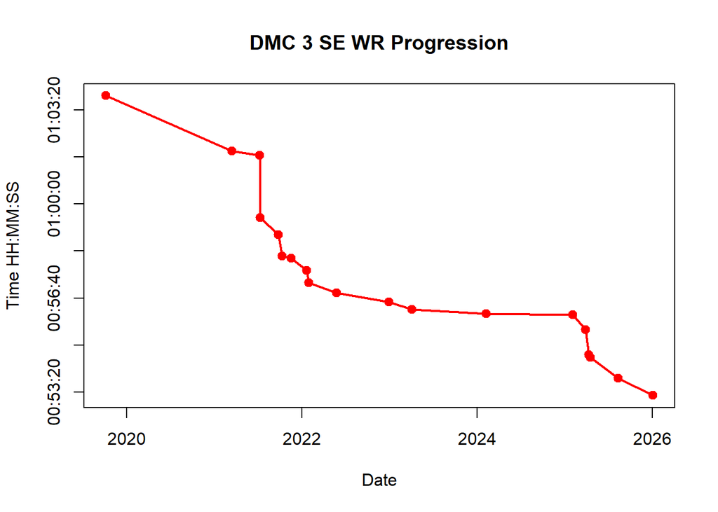

```r
plot(wr_data$ds, wr_data$y,
     type = "o",
     col = "red",
     pch = 19,
     lwd = 2,
     xlab = "Date",
     ylab = "Time HH:MM:SS",
     yaxt = "n",
     main = "DMC 3 SE WR Progression" )
ticks = pretty(wr_data$y)
axis(2, at = ticks, labels = format(hms::as_hms(ticks)))
```

```r
print(wr_data)
```

```
##            ds    y
## 1  2019-10-06 3830
## 2  2021-03-15 3713
## 3  2021-07-08 3703
## 4  2021-07-11 3571
## 5  2021-09-26 3535
## 6  2021-10-11 3489
## 7  2021-11-17 3485
## 8  2022-01-22 3459
## 9  2022-01-29 3433
## 10 2022-05-27 3411
## 11 2022-12-30 3392
## 12 2023-04-06 3376
## 13 2024-02-09 3367
## 14 2025-02-05 3364
## 15 2025-03-29 3333
## 16 2025-04-11 3279
## 17 2025-04-18 3274
## 18 2025-08-13 3229
## 19 2026-01-04 3193
```

# Checking Trends With Linear Regression

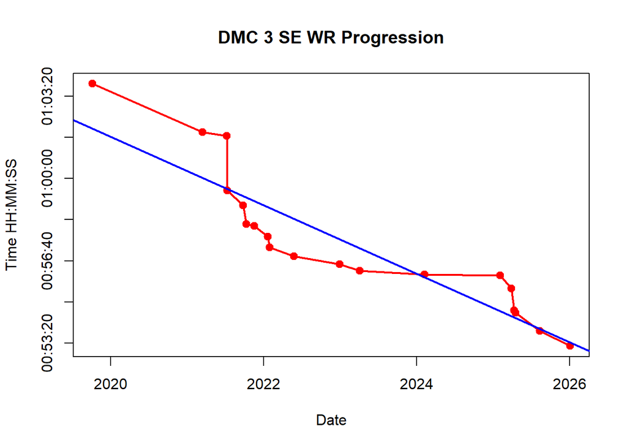

```r
model = lm(wr_data$y ~ wr_data$ds, data=wr_data)
plot(wr_data$ds, wr_data$y,
     type = "o",
     col = "red",
     pch = 19,
     lwd = 2,
     xlab = "Date",
     ylab = "Time HH:MM:SS",
     yaxt = "n",
     main = "DMC 3 SE WR Progression" )
ticks = pretty(wr_data$y)
axis(2, at = ticks, labels = format(hms::as_hms(ticks)))
abline(model, col = "blue", lwd = 2)
```

```r
summary(model)
```

```
##
## Call:
## lm(formula = wr_data$y ~ wr_data$ds, data = wr_data)
##
## Residuals:
##     Min      1Q  Median      3Q     Max
## -95.686 -60.360  -5.519  41.768 127.638
##
## Coefficients:
##               Estimate Std. Error t value Pr(>|t|)
## (Intercept) 7859.46234  494.66877  15.888 1.24e-11 ***
## wr_data$ds    -0.22768    0.02549  -8.931 7.90e-08 ***
## ---
## Signif. codes:  0 '***' 0.001 '**' 0.01 '*' 0.05 '.' 0.1 ' ' 1
##
## Residual standard error: 72.98 on 17 degrees of freedom
## Multiple R-squared:  0.8243, Adjusted R-squared:  0.814
## F-statistic: 79.77 on 1 and 17 DF,  p-value: 7.901e-08
```

The slope coefficient of *-0.22768* means on average that the DMC 3 SE WR roughly decreases by *0.22768* seconds a day and confirms the downward trend of the plot. The p-value of *7.901e-08* is very small and implies that the downward trend is significant and not likely be due to random variation. (Although random elements are also to be factored in the DMC 3 SE Speedrun, it is mostly skill based and execution heavy.) The Multiple R-Squared value of *0.8243* suggests that the linear trend explains roughly *82.43%* of the variation WR Progression, a value this high implies the trend captures most of the movement of the data.

# Prophet Forecasting Model

```r
wr_model = prophet(wr_data,
                   yearly.seasonality = FALSE,
                   weekly.seasonality = FALSE,
                   daily.seasonality = FALSE)
```

```
## n.changepoints greater than number of observations. Using 14
```

I will be using yearly observations to forecast the dataset, the seasonal components will be turned off and modelling the trend will be the main focus.

## Forecasting Future Speedruns

```r
future_wr = make_future_dataframe(wr_model, periods = 5, freq = "year")
forecast = predict(wr_model, future_wr)
```

## Forecast Plot

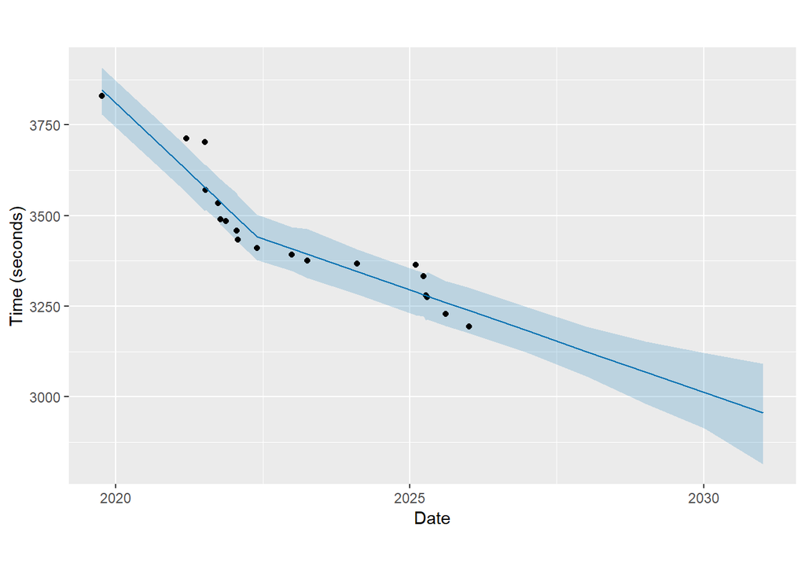

```r
plot(wr_model, forecast,
     xlab = "Date",
     ylab = "Time (seconds)")
```

This is the Prophet forecast for the DMC 3 SE WR Progression. The black dots are from the dataset, the blue line shows the model’s estimated trend and future predictions. The shaded area represents the uncertainty interval, this is a range where future WRs are likely to happen.

# Further Discussion

This goes without saying that this should not be used as a definitive way to predict the future WR of this speedrun, as there are many factors that can influence when a new WR has been recorded such as how many active runners are playing the game at a single moment, which is not included in this data.

Another piece of information I want to mention is that speedrunners use a tool called LiveSplit, which keeps track of their run time, and individual times in a segment of a run. The best times of each segment in the run is saved and over time is added up to make a “Sum of Best”, which is not included in this data set. The Sum of Best (SoB) shows the theoretical best time for a speedrunner and for some of these runners, their SoB is around the 00:50:xx mark. It is definitely doable, it is now only a matter of when will it happen. With the top 5 consisting of all previous WR holders, will it be them or someone new who will take it?

[figure not shown]

Top 5 Leaderboard as of 17.3.2026

# Conclusion

The DMC 3 SE speedrun has come a long way, with the current WR being around 10 minutes faster than what it was in 2019, and it will continue to to follow that downward trend. This can be certain as speedrunning is an ever-evolving practice that constantly aims to get the lowest time as possible. The linear regression model confirms that the downward trend is not due to random variation and is significant. Using the Prophet forecasting, it is predicted by 2030 that the speedrun will be close to 3000 seconds (50 minutes), but as mentioned prior, SoB shows there is a possibility to reach that time if the run has little to no flaws, so there could be a possibility someone gets that time earlier than what Prophet anticipates.

I would like to thank the DMC Speedrun Community for making this project possible, and I would like to thank WaifuRuns for making his informative video on the WR history.

# References

- DMC 3 SE Speedrun Leaderboard: https://www.speedrun.com/dmc3se
- DMC Wiki: https://dmc.wiki/dmc3:start
- The Story of How Speedrunning Took Over Devil May Cry 3 by WaifuRuns: https://youtu.be/0OBNvmXm9bw?si=IfstJMrT0gx1jXkF
- How Speedrunners Beat Devil May Cry 3 in Under 55 Minutes by WaifuRuns: https://youtu.be/jcFutsBtFVY?si=GteddQtMXmy9j7DN